[OHI Science](http://ohi-science.org) | [Citation policy](http://ohi-science.org/citation-policy/)

# OHI: Species subgoal for GBMF

Compiled on Thu Apr 12 11:31:14 2018 by ohara

```r
knitr::opts_chunk$set(fig.width = 6, fig.height = 4, fig.path = 'Figs/',
                      echo = TRUE, message = FALSE, warning = FALSE)

library(rgdal)
library(raster)
library(data.table)

source('~/github/ohiprep/src/R/common.R')
library(tidyverse) ### why not in common.R?
library(stringr)
library(sf)

goal     <- 'globalprep/spp_ico'
scenario <- 'v2018'
dir_goal_anx <- file.path(dir_M, 'git-annex', goal, scenario)
dir_goal  <- file.path('~/github/ohiprep', goal, scenario)

dir_data_am <- file.path(dir_M, 'git-annex/globalprep', '_raw_data/aquamaps/d2017')

### set up provenance tracking for this script:
# library(provRmd); prov_setup()

source(file.path(dir_goal, 'spp_fxn.R'))
```

# 1 Summary

Spatial data from IUCN and Aquamaps is combined with extinction risk information from IUCN to generate regional scores for the Species subgoal. A region’s status is based upon an area-weighted average of species health across each global reporting region.

From Halpern et al (2012):

> The target for the Species sub-goal is to have all species at a risk status of Least Concern. We scaled the lower end of the biodiversity goal to be 0 when 75% species are extinct, a level comparable to the five documented mass extinctions and would constitute a catastrophic loss of biodiversity. The Status of assessed species was calculated as the area- and threat status-weighted average of the number of threatened species within each 0.5 degree grid cell.

**Mean risk status per cell:**

$$\bar{R}_{cell} = \frac{\displaystyle\sum_{species}(Risk)}{n_{spp}}$$

**Species goal model**

$$X_{SPP} = \frac{((1 - \bar{R}_{SPP}) - 0.25)}{(1 - 0.25)} * 100%$$

where:

- $X_{SPP}$ is Species goal status
- $\bar{R}_{cell}$ is mean extinction risk for one cell
- $\bar{R}_{SPP}$ is area-weighted mean extinction risk for a region
- $A_{cell}$ is cell area
- $pA_{cell-rgn}$ is percent of cell area included in region
- *Risk* is scaled value for species extinction risk category, based on:
  - ‘LC’ = 0.0, ‘NT’ = 0.2, ‘VU’ = 0.4, ‘EN’ = 0.6, ‘CR’ = 0.8, ‘EX’ = 1.0
- SPP trend will be calculated using time series of categories based on current and past assessments.

# 2 Data Sources

IUCN:

- **Reference**:
  - IUCN 2016. The IUCN Red List of Threatened Species. Version 2016-3. http://www.iucnredlist.org.
    - Shapefiles available from: http://www.iucnredlist.org/technical-documents/spatial-data
    - **Downloaded**: 16 December 2016.
  - BirdLife International and NatureServe (2016) Bird species distribution maps of the world. BirdLife International, Cambridge, UK and NatureServe, Arlington, USA.
    - Zipped shapefile available from BirdLife International.
    - **Downloaded**: 23 December 2016.
- **Description**: Shapefiles containing polygons of assessed species ranges; each shapefile represents all assessed species within a comprehensively-assessed (i.e. >90% assessed) taxonomic group.
- **Native data resolution**: NA
- **Time range**: NA
- **Format**: Shapefile

AquaMaps:

- **Reference**:
  - Kaschner, K., J. Rius-Barile, K. Kesner-Reyes, C.Garilao, S.O. Kullander, T. Rees and R. Froese (2015). AquaMaps: Predicted range maps for aquatic species. World wide web electronic publication, www.aquamaps.org, Version 08/2015.
    - **Downloaded**: August 2015.
- **Description**: .sql files containing information to recreate rasters of cell attributes and cell-by-cell probability of occurrence for 22889 marine species.
- **Native data resolution**: 0.5° latitude and longitude
- **Time range**: NA
- **Format**: SQL database files converted into .csv

# 3 Methods

## 3.1 Spatialize species information using AquaMaps and IUCN spatial data

Each dataset is now set up to denote species presence in half-degree cells; for each cell we identify the species present, and can calculate a mean risk category for the cell.

### 3.1.1 Assemble species list with most recent IUCN scores

```r
spp_scored_file <- file.path(dir_goal, 'int', 'spp_list_scored.csv')

if(!file.exists(spp_scored_file)) {
  ### get time series of categories and trends.
  ### NOTE: risk_trend is positive for increasing risk, not increasing health.
  ###   It is the *annual* change in category score, not five-year-adjusted.
  spp_cat_ts_complete <- read_csv(file.path(dir_goal, 'int', 'spp_cat_timeseries_raw.csv')) %>%
    select(iucn_sid, year, cat_ts, cat_ts_score) %>%
    complete(year = full_seq(year, 1), nesting(iucn_sid)) %>%
    arrange(iucn_sid, year) %>%
    group_by(iucn_sid) %>%
    fill(cat_ts, cat_ts_score) %>%
      ### fills forward to most recent assessment year; older category valid til new assessment
    fill(cat_ts, cat_ts_score, .direction = 'up') %>%
      ### fills back from first non-NE or DD assessment; assume early status is same as first assessment
    ungroup() %>%
    filter(year >= 2000)

  ### set up a quick lookup to score the unmatched species
  cat_scores <- spp_cat_ts_complete %>%
    select(cat = cat_ts, score = cat_ts_score) %>%
    distinct() %>%
    arrange(score)
  cat_scores <- cat_scores$score %>%
    setNames(cat_scores$cat)

  spp_scored <- read_csv(file.path(dir_goal, 'int/spp_list.csv')) %>%
    filter(!(is.na(map_iucn_sid) & is.na(am_sid))) %>%
    mutate(spatial_source = ifelse(!is.na(map_iucn_sid), 'iucn', NA),
           spatial_source = ifelse(is.na(spatial_source) & !is.na(am_sid), 'am', spatial_source)) %>%
    left_join(spp_cat_ts_complete, by = 'iucn_sid')

  ### need to tidy up species from AM with no IUCN match.
  ### * set up the years
  spp_scored <- spp_scored %>%
    mutate(year = ifelse(is.na(year), list(unique(year)), year)) %>%
    unnest(year) %>%
    filter(!is.na(year)) %>%
    mutate(assess_year  = year + 1,
           cat_ts       = ifelse(is.na(cat_ts), category, cat_ts),
           cat_ts_score = ifelse(is.na(cat_ts_score), cat_scores[cat_ts], cat_ts_score)) %>%
      ### using the lookup from above
      ### * set up the category scores
    filter(!is.na(cat_ts_score)) %>% ### ditch any DD and NE species
    select(-category, -sciname, -spp_group, -cat_ts, -assess_year) %>%
    distinct()

  write_csv(spp_scored, spp_scored_file)
}
```

### 3.1.2 Generate cell-by-cell summary of species

```r
tot_sum_gbmf_file <- file.path(dir_goal, 'summary/spp_summary_gbmf.csv')

if(!file.exists(tot_sum_gbmf_file)) {

  spp_scored <- read_csv(file.path(dir_goal, 'int', 'spp_list_scored.csv'),
                         col_types = 'cddccdd') %>%
      rename(cat_score   = cat_ts_score) %>%
    filter(year == 2016) %>%
    select(-year)

  ### read in AquaMaps species-cell file
  am_cells_spp_file <- file.path(dir_goal_anx, 'int', 'am_spp_cells_d2017.csv')
  if(!file.exists(am_cells_spp_file)) {
    am_cells_spp <- read_csv(file.path(dir_data_am, 'csv/hcaf_species_native.csv'))

    am_cells <- read_tsv(file.path(dir_data_am, 'csv/hcaf_v6.csv')) %>%
      select(loiczid = LOICZID, CsquareCode)

    am_cells_spp <- am_cells_spp %>%
      left_join(am_cells, by = 'CsquareCode') %>%
      # filter(probability > 0) %>%
      select(am_sid = SpeciesID, loiczid) %>%
      distinct()
    write_csv(am_cells_spp, am_cells_spp_file)
  } else {
    if(!exists('am_cells_spp')) am_cells_spp <- read_csv(am_cells_spp_file)
  }

  ### read in IUCN species-cell file
  if(!exists('iucn_cells_spp')) {
    iucn_cells_spp <- read_csv(file.path(dir_goal_anx, '../v2017/int', 'iucn_spp_cells_d2016.csv')) %>%
      distinct()
  }


  rgn_cell_lookup <- extract_cell_id_per_region(reload = FALSE)
  # x <- get_rgn_names()
  loiczid_rast <- get_loiczid_raster()
  # gav <- readOGR(dsn = file.path(dir_M, 'git-annex/globalprep/_raw_data',
  #                                    'Geology_OffshoreGaviota'),
  #                    layer = 'Geology_OffshoreGaviota') %>%
  #   spTransform(proj4string(loiczid_rast)) %>%
  #   rgeos::gUnaryUnion()
  # bbox(gav)
  #          min        max
  # x -120.37975 -120.18518
  # y   34.40583   34.47089
  gav_bbox <- raster::extent(-121.5, -119, 33.5, 35)

  am_cell_area <- read_tsv(file.path(dir_data_am, 'csv/hcaf_v6.csv')) %>%
      select(loiczid = LOICZID, cell_area = CellArea, ocean_area = OceanArea)

  gav_cells <- data.frame(rgn_id = 1000,
                          rgn_name = 'Gaviota',
                          loiczid = loiczid_rast %>%
                            raster::extract(gav_bbox) %>%
                            unlist(),
                          proportionArea = 1) %>%
    left_join(am_cell_area, by = 'loiczid')

  gbmf_cell_lookup <- rgn_cell_lookup %>%
    filter(rgn_id %in% c('japan' = 210, 'nz' = 162, 'cuba' = 112)) %>%
    bind_rows(gav_cells)

  am_c_s_g_file <- file.path(dir_goal_anx, 'int', 'am_cells_spp_gbmf.csv')

  if(!file.exists(am_c_s_g_file)) { ### test for the AquaMaps one; assume IUCN is same
    am_cells_spp_gbmf <- am_cells_spp %>%
      inner_join(gbmf_cell_lookup, by = 'loiczid')
    iucn_cells_spp_gbmf <- iucn_cells_spp %>%
      inner_join(gbmf_cell_lookup, by = 'loiczid')

    write_csv(am_cells_spp_gbmf,   am_c_s_g_file)
    write_csv(iucn_cells_spp_gbmf, file.path(dir_goal_anx, 'int', 'iucn_cells_spp_gbmf.csv'))
  }

  iucn_cells_spp_sum <- iucn_cells_spp_gbmf %>%
    inner_join(spp_scored %>%
                 filter(!is.na(map_iucn_sid)),
               by = 'iucn_sid') %>%
    group_by(loiczid, rgn_id, rgn_name) %>%
    summarize(n_spp = n(), mean_risk = mean(cat_score))

  am_cells_spp_sum <- am_cells_spp_gbmf %>%
    inner_join(spp_scored %>%
                 filter(is.na(map_iucn_sid)), ### Presumably any spp w/o IUCN IDs will be from AM
               by = 'am_sid') %>%
    group_by(loiczid, rgn_id, rgn_name) %>%
    summarize(n_spp = n(), mean_risk = mean(cat_score))

  tot_cells_spp_sum <- bind_rows(iucn_cells_spp_sum, am_cells_spp_sum) %>%
    group_by(loiczid, rgn_id, rgn_name) %>%
    summarize(mean_risk = sum(mean_risk * n_spp) / sum(n_spp),
              n_spp = sum(n_spp))

  write_csv(tot_cells_spp_sum, tot_sum_gbmf_file)
}
```

## 3.2 Determine species by region

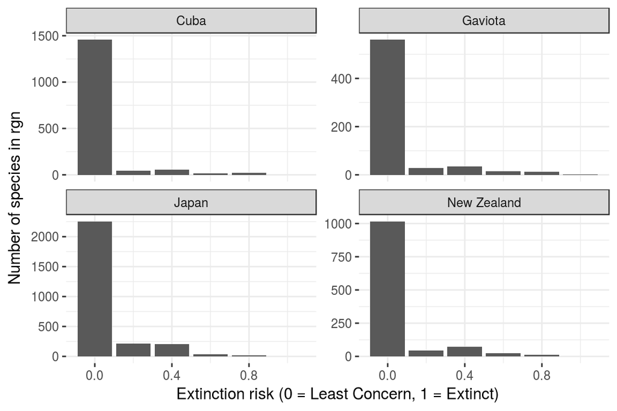

```r
spp_basic_info <- read_csv(file.path(dir_goal, 'int', 'spp_list_scored.csv'),
                       col_types = 'cddccdd') %>%
  rename(cat_score   = cat_ts_score) %>%
  filter(year == 2016) %>%
  left_join(read_csv(file.path(dir_goal, 'int', 'spp_list.csv')) %>%
              select(iucn_sid, am_sid, sciname),
            by = c('iucn_sid', 'am_sid')) %>%
  select(-year, -map_subpop)

am_spp_gbmf <- read_csv(file.path(dir_goal_anx, 'int', 'am_cells_spp_gbmf.csv'),
                        col_types = 'cddcddd') %>%
  group_by(am_sid, rgn_id, rgn_name) %>%
  summarize(rgn_range_km2 = sum(proportionArea * cell_area * ocean_area)) %>%
  left_join(spp_basic_info, by = 'am_sid')

iucn_spp_gbmf <- read_csv(file.path(dir_goal_anx, 'int', 'iucn_cells_spp_gbmf.csv'),
                          col_types = 'cddcdddcddd') %>%
  rename(map_iucn_sid = iucn_sid) %>%
  group_by(map_iucn_sid, rgn_id, rgn_name) %>%
  summarize(rgn_range_km2 = sum(proportionArea * cell_area)) %>%
  left_join(spp_basic_info, by = c('map_iucn_sid'))

spp_list_all <- am_spp_gbmf %>%
  filter(spatial_source == 'am') %>%
  bind_rows(iucn_spp_gbmf) %>%
  filter(!is.na(cat_score))

write_csv(spp_list_all, file.path(dir_goal, 'summary/spp_list_gbmf.csv'))

# spp_list_all$rgn_name %>% table()
#        Cuba     Gaviota       Japan New Zealand
#        1600         595        2743        1173

ggplot(spp_list_all, aes(x = cat_score)) +
  theme_bw() +
  theme(panel.border = element_blank()) +
  geom_bar() +
  facet_wrap( ~ rgn_name, scales = 'free_y') +
  labs(x = 'Extinction risk (0 = Least Concern, 1 = Extinct)',
       y = 'Number of species in rgn')
```

```r
ggsave(file.path(dir_goal, 'gbmf_maps/risk_spp_barchart.png'))
```

## 3.3 Map mean risk scores, spp status, and n_spp for each region

```r
am_cell_area <- read_tsv(file.path(dir_data_am, 'csv/hcaf_v6.csv')) %>%
    select(loiczid = LOICZID, cell_area = CellArea, ocean_area = OceanArea)

gaviota_status <- read_csv(file.path(dir_goal, 'summary/spp_summary_gbmf.csv')) %>%
  left_join(am_cell_area, by = 'loiczid') %>%
  filter(rgn_id == 1000) %>%
  group_by(rgn_name) %>%
  summarize(rgn_mean_risk = sum(mean_risk * ocean_area) / sum(ocean_area),
            rgn_status = 100 * (.75 - rgn_mean_risk) / .75)
```

```r
loiczid_rast <- get_loiczid_raster()
ctrys50m <- rnaturalearth::ne_countries(scale = 10, type = 'countries', returnclass = 'sf') %>%
  select(iso_a3, iso_n3, admin)
ca_shp   <- rnaturalearth::ne_states(geounit = 'United States of America', returnclass = 'sf') %>%
  filter(woe_name == 'California')

cells_sum <- read_csv(file.path(dir_goal, 'summary/spp_summary_gbmf.csv')) %>%
  mutate(status = 100 * (.75 - mean_risk) / .75)

rgns <- cells_sum$rgn_id %>%
  unique() %>%
  set_names(cells_sum$rgn_name %>% unique())

ohi_rgns_shp <- st_read(file.path(dir_M, 'git-annex/globalprep/spatial/v2017/regions_2017_update.shp')) %>%
  filter(rgn_type == 'eez' & rgn_id %in% rgns) %>%
  select(rgn_id, rgn_name, geometry) %>%
  st_transform(4326)
gav_shp <- st_read(file.path(dir_M, 'git-annex/globalprep/_raw_data',
                             'Geology_OffshoreGaviota',
                             'Geology_OffshoreGaviota_mol_v_court.shp')) %>%
  st_transform(4326) %>%
  select(geometry) %>%
  mutate(rgn_id = 1000, rgn_name = 'Gaviota')
```

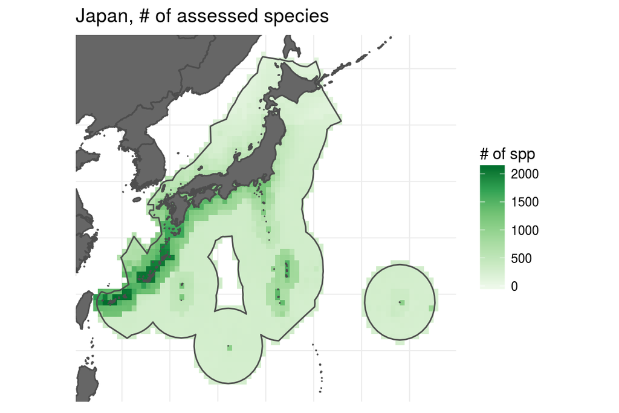

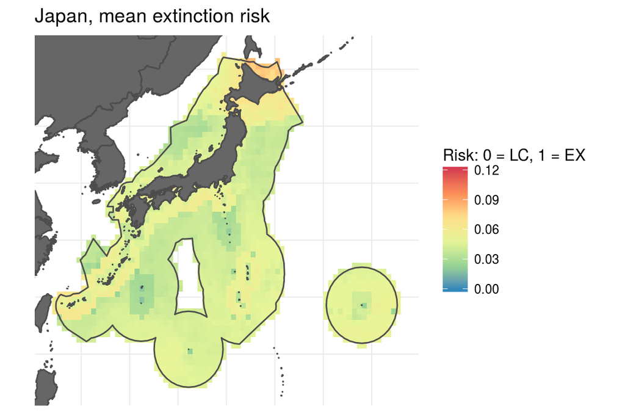

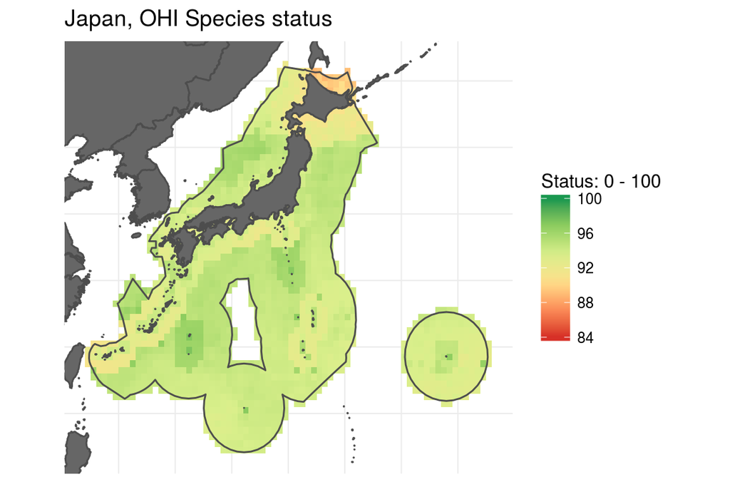

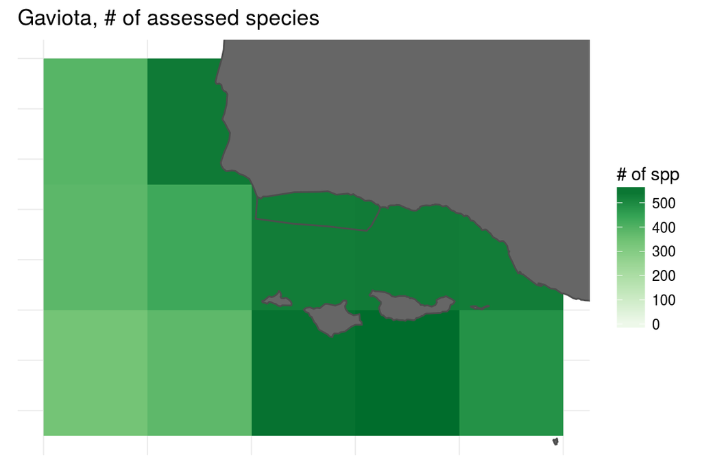

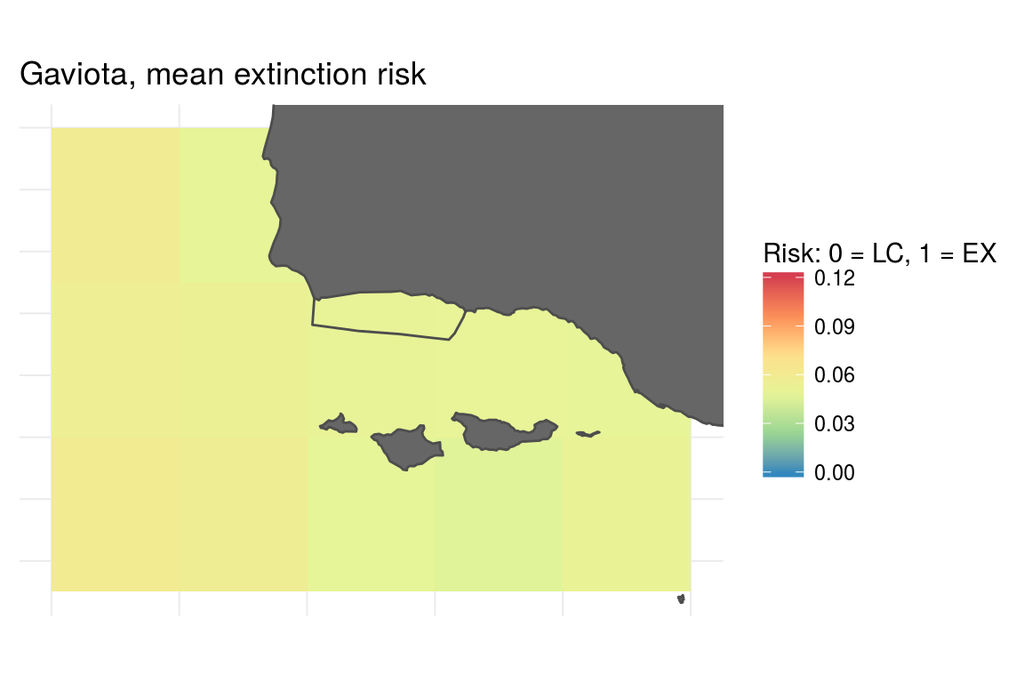

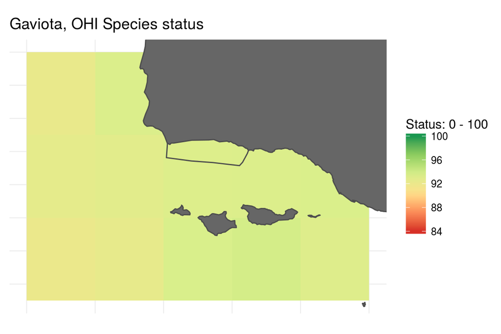

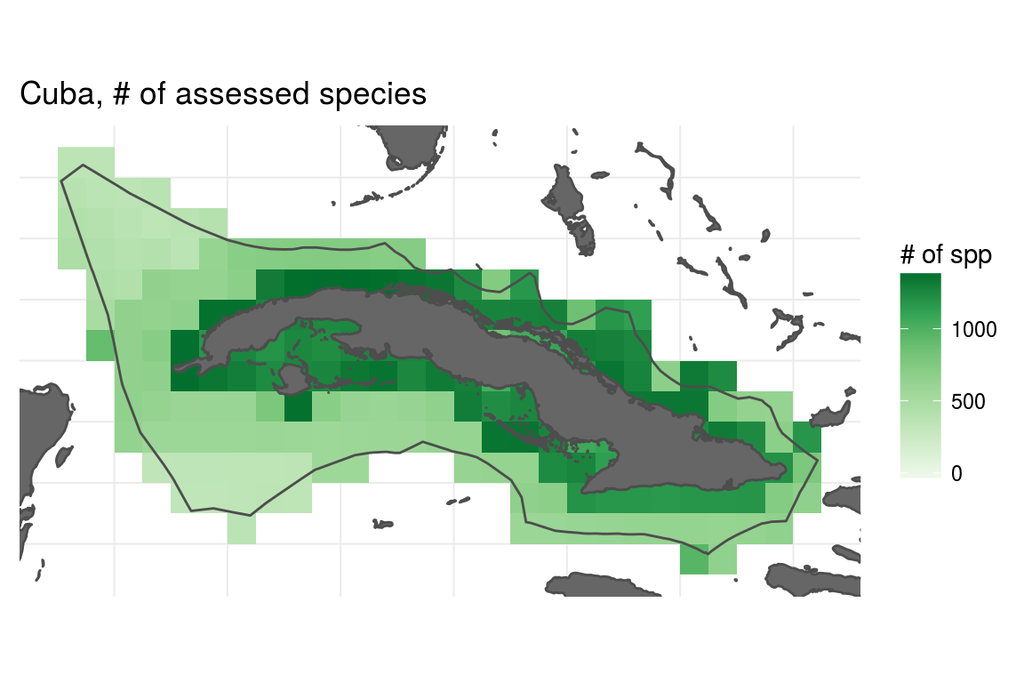

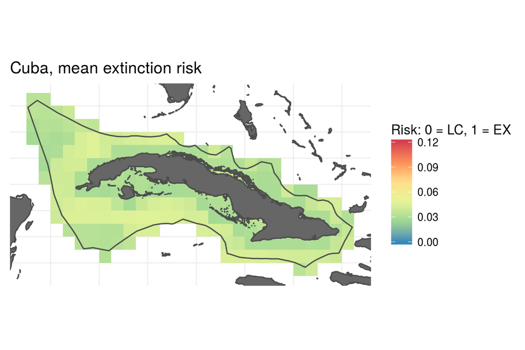

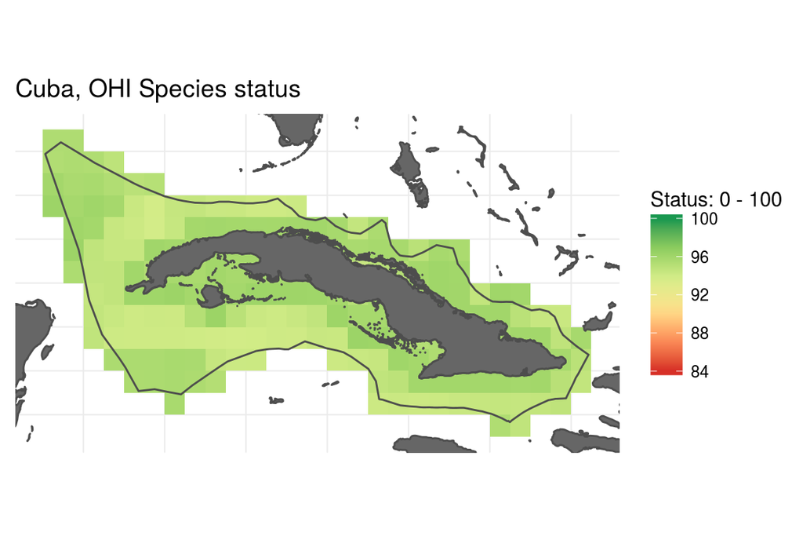

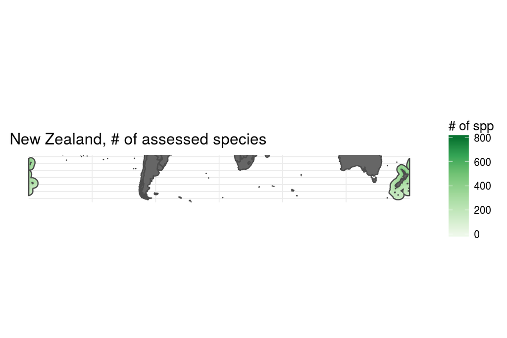

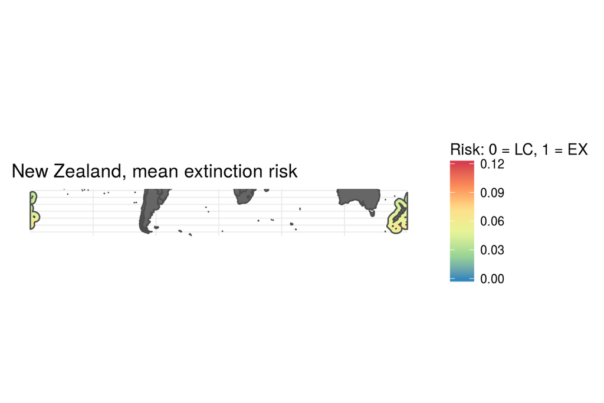

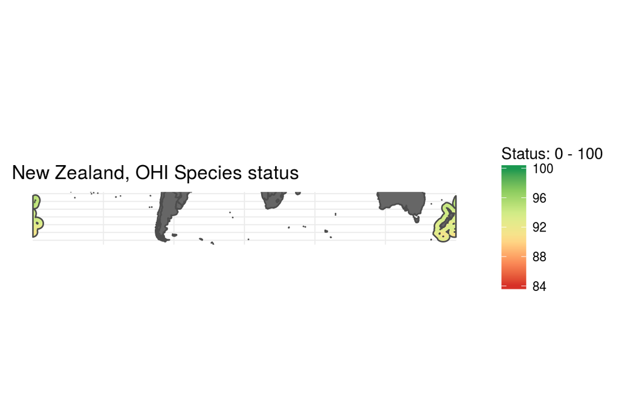

```r
plot_rast_map <- function(shp, cells_df, land_shp, column) {
  ### cells_df <- tot_cells_spp_sum %>% filter(rgn_id == 162)
  ### column <- 'n_spp'
  ### shp <- ohi_rgns_shp %>% filter(rgn_id == 162)

  rast <- subs(loiczid_rast, cells_df, by = 'loiczid', which = column) %>%
    raster::trim()

  ext <- extent(rast)
  rast_df <- rast %>%
    rasterToPoints() %>%
    as.data.frame()

  tmp_plot <- ggplot() +
    theme_bw() +
    geom_raster(data = rast_df, aes(x, y, fill = layer)) +
    geom_sf(data = shp, aes(), fill = NA, color = 'grey30', size = .5) +
    geom_sf(data = land_shp, aes(), fill = 'grey40', color = 'grey30', size = .5) +
    xlim(c(ext[1:2])) +
    ylim(c(ext[3:4])) +
    theme(axis.title = element_blank(),
          axis.text  = element_blank(),
          axis.ticks = element_blank(),
          panel.border = element_blank())

  return(tmp_plot)
}

for(rgn in rgns) {
  # rgn <- 112
  if(rgn == 1000) {
    shp <- gav_shp
    land_shp <- ca_shp
  } else {
    shp <- ohi_rgns_shp %>%
      filter(rgn_id == rgn)
    land_shp <- ctrys50m
  }
  df <- cells_sum %>% filter(rgn_id == rgn)
  rgn_nm <- df$rgn_name[1]

  map_nspp <- plot_rast_map(shp, df, land_shp, column = 'n_spp') +
    scale_fill_distiller(palette = 'Greens', direction = 1,
                         limits = c(0, NA)) +
    labs(title = sprintf('%s, # of assessed species', rgn_nm),
         fill = '# of spp')
  map_risk <- plot_rast_map(shp, df, land_shp, column = 'mean_risk') +
    scale_fill_distiller(palette = 'Spectral',
                         limits = c(0, .12)) +
    labs(title = sprintf('%s, mean extinction risk', rgn_nm),
         fill = 'Risk: 0 = LC, 1 = EX')
  map_status <- plot_rast_map(shp, df, land_shp, column = 'status') +
    scale_fill_distiller(palette = 'RdYlGn', direction = 1,
                         limits = c(84, 100)) +
    labs(title = sprintf('%s, OHI Species status', rgn_nm),
         fill = 'Status: 0 - 100')

  print(map_nspp)
  print(map_risk)
  print(map_status)

  ggsave(file.path(dir_goal, 'gbmf_maps', sprintf('%s_nspp.png', tolower(rgn_nm))),
                   dpi = 300, plot = map_nspp)
  ggsave(file.path(dir_goal, 'gbmf_maps', sprintf('%s_risk.png', tolower(rgn_nm))),
                   dpi = 300, plot = map_risk)
  ggsave(file.path(dir_goal, 'gbmf_maps', sprintf('%s_status.png', tolower(rgn_nm))),
                   dpi = 300, plot = map_status)
}
```

```r
# loiczid_rast <- get_loiczid_raster()

cells_sum <- read_csv(file.path(dir_goal, 'summary/spp_summary_gbmf.csv')) %>%
  mutate(status = 100 * (.75 - mean_risk) / .75)

nspp_rast  <- subs(loiczid_rast, cells_sum, by = 'loiczid', which = 'n_spp',
                   filename = file.path(dir_goal, 'gbmf_maps/raster_nspp.tif'),
                   overwrite = TRUE)
risk_rast  <- subs(loiczid_rast, cells_sum, by = 'loiczid', which = 'mean_risk',
                   filename = file.path(dir_goal, 'gbmf_maps/raster_mean_risk.tif'),
                   overwrite = TRUE)
status_rast <- subs(loiczid_rast, cells_sum, by = 'loiczid', which = 'status',
                   filename = file.path(dir_goal, 'gbmf_maps/raster_status.tif'),
                   overwrite = TRUE)
```

```r
# prov_wrapup(commit_outputs = FALSE)
```